# Dictionary-based text analysis and UK-US spelling conversion with quanteda

Stefan Müller and Kenneth Benoit

# 1. Introduction

Built on the [**quanteda**](http://www.quanteda.io) package for text analysis, **quanteda.dictionaries** consists of dictionaries for text analysis and associated utilities. In this vignette, we show how to replicate the main features of the [LIWC software](https://liwc.wpengine.com/compare-versions/) with packages provided by the Quanteda Initiative. If you prefer to have a complete, stand-alone user interface, then you should purchase and use the [LIWC standalone software](http://liwc.wpengine.com). Moreover, the package contains dictionaries to homogenize (or homogenise!) the spellings of US and British English.

# 2. Using dictionaries with quanteda

```r
library(quanteda)
library(quanteda.dictionaries)
```

## 2.1 Accessing texts

To access texts for scoring sentiment, we will use the movie reviews corpus from Pang, Lee, and Vaithyanathan (2002), found in the [**quanteda.corpora**](http://github.com/quanteda/quanteda.corpora) package. This requires that you have installed that package. (If you want to use your own texts, we recommend the [**readtext**](https://github.com/quanteda/readtext) package for reading in your texts.)

```r
data(data_corpus_movies, package = "quanteda.corpora")
```

## 2.2 Analyze sentiment

Next, we analyze sentiment of text. If you have purchased the LIWC dictionary, you can load it as a **quanteda**-formatted dictionary in the following way.

```r
liwc2007dict <- dictionary(file = "LIWC2007.cat", format = "wordstat")
tail(liwc2007dict, 1)
# Dictionary object with 1 primary key entry and 2 nested levels.
# - [SPOKEN CATEGORIES]:
#   - [ASSENT]:
#     - absolutely, agree, ah, alright*, aok, aw, awesome, cool, duh, ha, hah, haha*, heh*, hm*, huh, lol, mm*, oh, ok, okay, okey*, rofl, uhhu*, uhuh, yah, yay, yea, yeah, yep*, yes, yup
#   - [NON-FLUENCIES]:
#     - er, hm*, sigh, uh, um, umm*, well, zz*
#   - [FILLERS]:
#     - blah, idon'tknow, idontknow, imean, ohwell, oranything*, orsomething*, orwhatever*, rr*, yakn*, ykn*, youknow*
```

While you can use the LIWC dictionary which you need to purchase, in this example we use the NRC sentiument dictionary object `data_dictionary_NRC`. The `liwcalike()` function from **quanteda.dictionaries** gives similar output to that from the LIWC stand-alone software. We use a collection of 2000 movie reviews classified as “positive” or “negative”, a corpus which comes with **quanteda.corpora**.

```r
output_nrc <- liwcalike(data_corpus_movies, data_dictionary_NRC)
head(output_nrc)
```

```
##           docname Segment  WC       WPS Sixltr   Dic anger anticipation
## 1 neg_cv000_29416       1 847  78.88889  12.75 19.36  0.71         2.95
## 2 neg_cv001_19502       2 278 240.00000  15.11 24.46  3.24         3.24
## 3 neg_cv002_17424       3 559 162.66667  13.42 21.29  1.07         2.86
## 4 neg_cv003_12683       4 594 239.50000  16.50 22.73  1.35         3.03
## 5 neg_cv004_12641       5 872 366.50000  12.50 19.38  1.26         1.49
## 6 neg_cv005_29357       6 753 671.00000  17.26 27.49  3.32         1.59
##   disgust fear  joy negative positive sadness surprise trust AllPunc
## 1    0.83 1.42 2.36     2.24     4.01    1.42     1.30  2.13   18.06
## 2    2.16 1.80 1.44     4.32     2.88    1.44     1.08  2.88   18.35
## 3    0.72 2.68 1.43     3.40     4.11    1.79     0.54  2.68   14.67
## 4    1.18 1.85 1.52     4.21     5.05    1.85     1.18  1.52   22.90
## 5    0.69 2.06 1.49     3.90     3.33    1.72     1.38  2.06   17.66
## 6    2.39 4.25 0.80     5.98     3.45    1.99     1.86  1.86   11.02
##   Period Comma Colon SemiC QMark Exclam Dash Quote Apostro Parenth OtherP
## 1   4.01  5.19  0.35  0.00  0.71   0.35 1.18  3.07    1.89       0  14.76
## 2   5.04  6.47  0.00  0.00  0.00   0.00 0.00  5.40    4.68       0  16.91
## 3   3.94  5.55  0.00  0.00  0.54   0.00 0.54  2.68    2.68       0  12.70
## 4   3.37  4.38  0.00  0.00  0.51   0.00 4.71  7.58    4.21       0  15.82
## 5   4.24  6.19  0.69  0.23  0.11   0.00 1.95  2.18    1.72       0  13.65
## 6   4.65  3.98  0.13  0.00  0.00   0.00 0.53  0.93    0.40       0   9.69
```

Next, we can use the `negative` and `positive` columns to estimate the net sentiment for each text by subtracting negative from positive words.

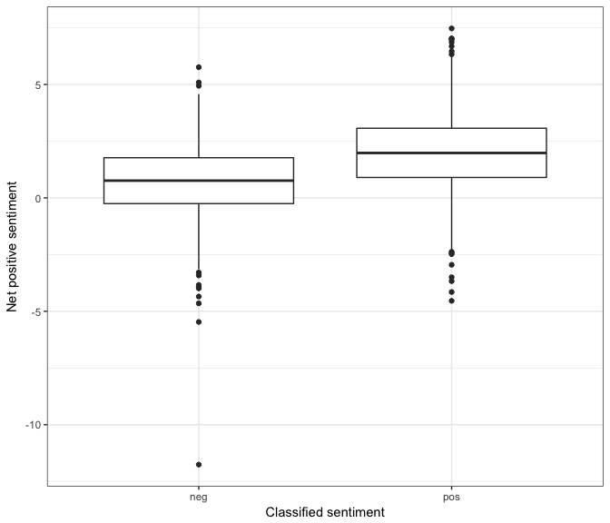

```r
output_nrc$net_positive <- output_nrc$positive - output_nrc$negative
output_nrc$sentiment <- docvars(data_corpus_movies, "Sentiment")

library(ggplot2)
# set ggplot2 theme
theme_set(theme_bw())
ggplot(output_nrc, aes(x = sentiment, y = net_positive)) +
    geom_boxplot() +
    labs(x = "Classified sentiment",
         y = "Net positive sentiment",
         main = "NRC Sentiment Dictionary")
```

We see that the median of the net positive sentiment from our dictionary analysis is higher for reviews that have been classified as being positive. To check whether the choice of dictionary had an impact on this result, we can rerun the analysis with a the General Inquirer *Positive* and *Negative* dictionary, an alternative sentiment dictionary provided in **quanteda.dictionaries**.

```r
output_geninq <- liwcalike(data_corpus_movies, data_dictionary_geninqposneg)
names(output_geninq)
```

```
##  [1] "docname"  "Segment"  "WC"       "WPS"      "Sixltr"   "Dic"
##  [7] "positive" "negative" "AllPunc"  "Period"   "Comma"    "Colon"
## [13] "SemiC"    "QMark"    "Exclam"   "Dash"     "Quote"    "Apostro"
## [19] "Parenth"  "OtherP"
```

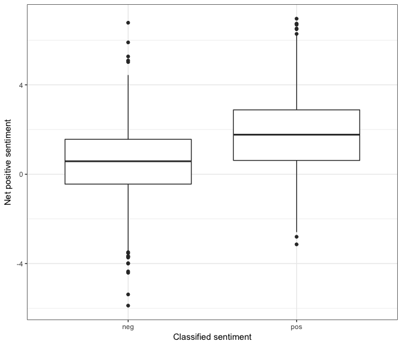

```r
output_geninq$net_positive <- output_geninq$positive - output_geninq$negative
output_geninq$sentiment <- docvars(data_corpus_movies, "Sentiment")

ggplot(output_geninq, aes(x = sentiment, y = net_positive)) +
    geom_boxplot() +
    labs(x = "Classified sentiment",
         y = "Net positive sentiment",
         main = "General Inquirer Sentiment Association")
```

We can also check the correlation of the estimated net positive sentiment for both the NRC Word-Emotion Association Lexicon and the General Inquirer Sentiment Association.

```r
cor.test(output_nrc$net_positive, output_geninq$net_positive)
```

```
##
##  Pearson's product-moment correlation
##
## data:  output_nrc$net_positive and output_geninq$net_positive
## t = 39.532, df = 1998, p-value < 2.2e-16
## alternative hypothesis: true correlation is not equal to 0
## 95 percent confidence interval:
##  0.6371508 0.6863810
## sample estimates:
##       cor
## 0.6624807
```

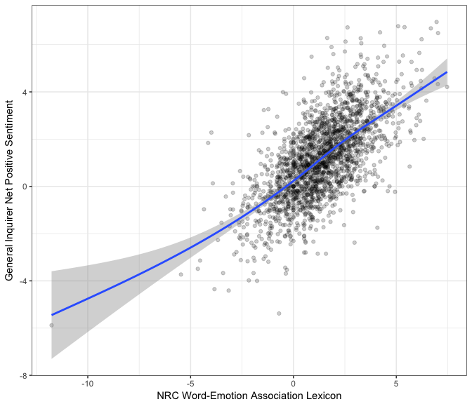

```r
cor_dictionaries <- data.frame(
    nrc = output_nrc$net_positive,
    geninq = output_geninq$net_positive
)

ggplot(data = cor_dictionaries, aes(x = nrc, y = geninq)) +
    geom_point(alpha = 0.2) +
    geom_smooth() +
    labs(x = "NRC Word-Emotion Association Lexicon",
         y = "General Inquirer Net Positive Sentiment",
         main = "Correlation for Net Positive Sentiment in Movie Reviews")
## `geom_smooth()` using method = 'gam'
```

## 2.3 User-created dictionaries

The LIWC software allows to build custom dictionaries created for specific research questions. With **quanteda**’s `dictionary()` function we can do the same.

```r
mydict <- dictionary(list(positive = c("great", "phantastic", "wonderful"),
                          negative = c("bad", "horrible", "terrible")))

output_custom_dict <- liwcalike(data_corpus_movies, mydict)
head(output_custom_dict)
```

```
##           docname Segment  WC       WPS Sixltr  Dic positive negative
## 1 neg_cv000_29416       1 847  78.88889   0.24 0.24     0.00     0.24
## 2 neg_cv001_19502       2 278 240.00000   0.00 0.00     0.00     0.00
## 3 neg_cv002_17424       3 559 162.66667   0.00 0.00     0.00     0.00
## 4 neg_cv003_12683       4 594 239.50000   0.17 0.17     0.00     0.17
## 5 neg_cv004_12641       5 872 366.50000   0.23 0.23     0.00     0.23
## 6 neg_cv005_29357       6 753 671.00000   0.40 0.40     0.13     0.27
##   AllPunc Period Comma Colon SemiC QMark Exclam Dash Quote Apostro Parenth
## 1   18.06   4.01  5.19  0.35  0.00  0.71   0.35 1.18  3.07    1.89       0
## 2   18.35   5.04  6.47  0.00  0.00  0.00   0.00 0.00  5.40    4.68       0
## 3   14.67   3.94  5.55  0.00  0.00  0.54   0.00 0.54  2.68    2.68       0
## 4   22.90   3.37  4.38  0.00  0.00  0.51   0.00 4.71  7.58    4.21       0
## 5   17.66   4.24  6.19  0.69  0.23  0.11   0.00 1.95  2.18    1.72       0
## 6   11.02   4.65  3.98  0.13  0.00  0.00   0.00 0.53  0.93    0.40       0
##   OtherP
## 1  14.76
## 2  16.91
## 3  12.70
## 4  15.82
## 5  13.65
## 6   9.69
```

## 2.4 Apply dictionary to segmented text

LIWC provides easy segmentation, through a GUI. With functions from the **quanteda** package, you can segment the texts yourself using `corpus_reshape()` or `corpus_segment()`. In the following example, we divide up the inaugural speeches by paragraphs and apply a sentiment dictionary.

```r
ndoc(data_corpus_inaugural)
```

```
## [1] 58
```

The initial inaugural corpus consists of 58 documents (one document per speech).

```r
inaug_corpus_paragraphs <- corpus_reshape(data_corpus_inaugural, to = "paragraphs")
ndoc(inaug_corpus_paragraphs)
```

```
## [1] 1513
```

When we divide the corpus into paragraphs, the number of documents increases to 1513. Next, we can apply the `liwcalike()` function to the reshaped corpus using the NRC Word-Emotion Association Lexicon.

```r
output_paragraphs <- liwcalike(inaug_corpus_paragraphs, data_dictionary_NRC)
head(output_custom_dict)
```

```
##           docname Segment  WC       WPS Sixltr  Dic positive negative
## 1 neg_cv000_29416       1 847  78.88889   0.24 0.24     0.00     0.24
## 2 neg_cv001_19502       2 278 240.00000   0.00 0.00     0.00     0.00
## 3 neg_cv002_17424       3 559 162.66667   0.00 0.00     0.00     0.00
## 4 neg_cv003_12683       4 594 239.50000   0.17 0.17     0.00     0.17
## 5 neg_cv004_12641       5 872 366.50000   0.23 0.23     0.00     0.23
## 6 neg_cv005_29357       6 753 671.00000   0.40 0.40     0.13     0.27
##   AllPunc Period Comma Colon SemiC QMark Exclam Dash Quote Apostro Parenth
## 1   18.06   4.01  5.19  0.35  0.00  0.71   0.35 1.18  3.07    1.89       0
## 2   18.35   5.04  6.47  0.00  0.00  0.00   0.00 0.00  5.40    4.68       0
## 3   14.67   3.94  5.55  0.00  0.00  0.54   0.00 0.54  2.68    2.68       0
## 4   22.90   3.37  4.38  0.00  0.00  0.51   0.00 4.71  7.58    4.21       0
## 5   17.66   4.24  6.19  0.69  0.23  0.11   0.00 1.95  2.18    1.72       0
## 6   11.02   4.65  3.98  0.13  0.00  0.00   0.00 0.53  0.93    0.40       0
##   OtherP
## 1  14.76
## 2  16.91
## 3  12.70
## 4  15.82
## 5  13.65
## 6   9.69
```

## 2.5 Export output to a spreadsheet

The LIWC software allows you to export the output from the dictionary analysis to a spreadsheet. We can also do this with **write.csv** or use packages such as **haven** or **rio** to save the `data.frame` in a custom file format.

```r
# save as csv file
write.csv(output_custom_dict, file = "output_dictionary.csv",
         fileEncoding = "utf-8")

# save as Excel file (xlsx)
library(rio)
rio::export(output_custom_dict, file = "output_dictionary.xlsx")
```

# 3. Homogeni[zs]e British and US English

**quanteda.dictionaries** contains a English UK-US spelling conversion dictionary which provide the ability to homogeni[zs]e the spellings of English by converting the spelling variants of one language to the other. The dictionary contains 1,800 roots and derivitives which are accessible [online](http://www.tysto.com/uk-us-spelling-list.html).

```r
txt <- c(uk = "endeavour to prioritise honour over esthetics",
         us = "endeavor to prioritize honor over aesthetics")
toks <- quanteda::tokens(txt)
```

If we want to change words from British English to US English we can use `tokens_replace()` from the **quanteda** package in combination with `data_dictionary_uk2us`.

```r
quanteda::tokens_replace(toks, data_dictionary_uk2us)
## tokens from 2 documents.
## uk :
## [1] "endeavor"   "to"         "prioritize" "honor"      "over"
## [6] "esthetics"
##
## us :
## [1] "endeavor"   "to"         "prioritize" "honor"      "over"
## [6] "esthetics"
```

To make all speelings British, we use `data_dictionary_us2uk` instead.

```r
quanteda::tokens_replace(toks, data_dictionary_us2uk)
## tokens from 2 documents.
## uk :
## [1] "endeavour"  "to"         "prioritise" "honour"     "over"
## [6] "aesthetics"
##
## us :
## [1] "endeavour"  "to"         "prioritise" "honour"     "over"
## [6] "aesthetics"
```

We can see the difference that this makes when converting the texts to a document-feature matrix:

```r
# original dfm
quanteda::dfm(toks)
## Document-feature matrix of: 2 documents, 10 features (40% sparse).
## 2 x 10 sparse Matrix of class "dfm"
##     features
## docs endeavour to prioritise honour over esthetics endeavor prioritize
##   uk         1  1          1      1    1         1        0          0
##   us         0  1          0      0    1         0        1          1
##     features
## docs honor aesthetics
##   uk     0          0
##   us     1          1

# homogeni[zs]ed dfm
quanteda::dfm(quanteda::tokens_replace(toks, data_dictionary_uk2us))
## Document-feature matrix of: 2 documents, 6 features (0% sparse).
## 2 x 6 sparse Matrix of class "dfm"
##     features
## docs endeavor to prioritize honor over esthetics
##   uk        1  1          1     1    1         1
##   us        1  1          1     1    1         1
```

## References

Pang, Bo, Lillian Lee, and Shivakumar Vaithyanathan. 2002. Thumbs up?: sentiment classification using machine learning techniques. In Proceedings of the ACL-02 conference on Empirical methods in natural language processing - Volume 10 (EMNLP ’02), Vol. 10. Association for Computational Linguistics, Stroudsburg, PA, USA, 79-86. DOI: https://doi.org/10.3115/1118693.1118704

Pennebaker, J.W., Chung, C.K., Ireland, M., Gonzales, A., & Booth, R.J. (2007). *The development and psychometric properties of LIWC2007*. [Software manual]. Austin, TX (http://www.liwc.net).

Saif Mohammad and Peter Turney (2013). “Crowdsourcing a Word-Emotion Association Lexicon.” *Computational Intelligence* 29(3), 436-465.

Stone, Philip J., Dexter C. Dunphy, and Marshall S. Smith. 1966. *The General Inquirer: A computer approach to content analysis.* Cambridge, MA: MIT Press.